# Modelos de Equações Estruturais Longitudinais - Exercício

Faculdade de Psicologia e de Ciências da Educação - UP

Tiago Ferreira

Para realizar este exercício recorremos a duas bases de dados criadas a partir dos resultados de um estudo conduzido pelo nosso grupo de investigação:  
- Ferreira, T., Cadima, J., Matias, M., Vieira, J. M., Leal, T., Verschueren, K., & Matos, P. M. (2018). Trajectories of parental engagement in early childhood among dual-earner families: Effects on child self-control. *Developmental Psychology, 54(4)*, 731–743. https://doi.org/10.1037/dev0000458

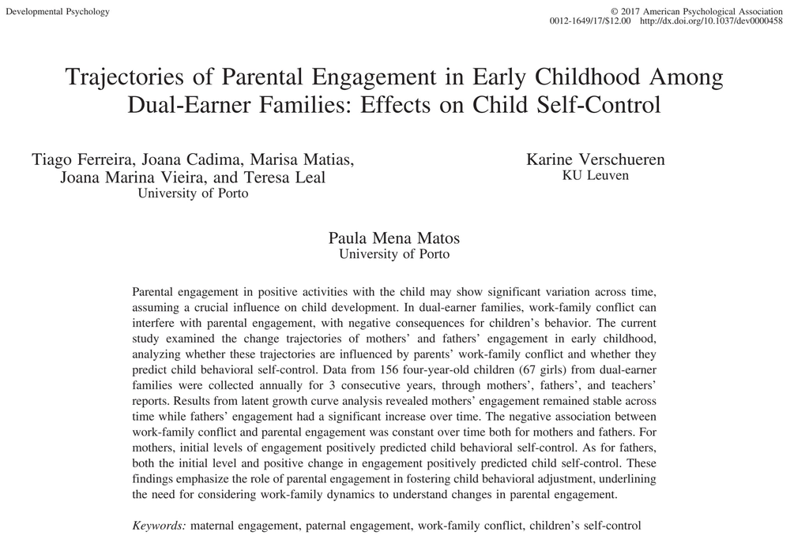

Neste estudo investigamos as trajetórias do envolvimento parental de pais e mães de crianças em idade pré-escolar. O envolvimento foi avaliado através de medidas de auto-relato, em três momentos temporais separados por um ano. foram simuladas duas bases de dados, uma para avaliar o modelo de medida (“df_parinv_1.csv”) e outra para testar vários modelos de crescimento latente (“df_parinv_2.csv”).

**PARTE I**

1. Iniciar o R e Importar base de dados no ficheiro “df_parinv_1.csv”;
2. Verificar as dimensões e nomes das variáveis na base de dados;

```
## [1] 900  18
```

```
##  [1] "Fath_t1.p1" "Fath_t1.p2" "Fath_t1.p3" "Fath_t2.p1" "Fath_t2.p2"
##  [6] "Fath_t2.p3" "Fath_t3.p1" "Fath_t3.p2" "Fath_t3.p3" "Moth_t1.p1"
## [11] "Moth_t1.p2" "Moth_t1.p3" "Moth_t2.p1" "Moth_t2.p2" "Moth_t2.p3"
## [16] "Moth_t3.p1" "Moth_t3.p2" "Moth_t3.p3"
```

3. Descrever a estrutura da base dados usando a função str();

```
## 'data.frame':    900 obs. of  18 variables:
##  $ Fath_t1.p1: num  1.96 2.89 1.99 3.31 2.15 ...
##  $ Fath_t1.p2: num  2.56 3.03 3.04 3.95 2.32 ...
##  $ Fath_t1.p3: num  2.2 4.04 2.56 3.24 2.94 ...
##  $ Fath_t2.p1: num  2.19 2.67 2.11 2.87 1.69 ...
##  $ Fath_t2.p2: num  2.34 2.98 2.47 3.08 2.04 ...
##  $ Fath_t2.p3: num  2.21 3.53 3.02 3.14 2.35 ...
##  $ Fath_t3.p1: num  1.81 3.07 1.9 3.22 2.82 ...
##  $ Fath_t3.p2: num  2.48 2.88 2.59 3.55 2.94 ...
##  $ Fath_t3.p3: num  2.46 3.47 2.3 3.93 3.22 ...
##  $ Moth_t1.p1: num  1.21 2.95 2.73 2.66 2.48 ...
##  $ Moth_t1.p2: num  1.85 3.39 3.07 3.02 3.1 ...
##  $ Moth_t1.p3: num  2.23 3.86 3.02 3.12 3.1 ...
##  $ Moth_t2.p1: num  2.11 2.8 3.07 2.07 2.48 ...
##  $ Moth_t2.p2: num  2.62 3.2 3.38 2.52 2.85 ...
##  $ Moth_t2.p3: num  2.55 3.51 3.48 2.43 2.69 ...
##  $ Moth_t3.p1: num  1.63 2.96 3.17 1.72 2.42 ...
##  $ Moth_t3.p2: num  2.18 3.55 3.56 2.13 3.26 ...
##  $ Moth_t3.p3: num  2.37 3.66 3.39 1.87 3.23 ...
```

4. Fazer o sumário das variáveis na base de dados;

```
##    Fath_t1.p1      Fath_t1.p2      Fath_t1.p3      Fath_t2.p1
##  Min.   :1.145   Min.   :1.323   Min.   :1.198   Min.   :0.880
##  1st Qu.:2.179   1st Qu.:2.392   1st Qu.:2.585   1st Qu.:2.215
##  Median :2.520   Median :2.716   Median :2.964   Median :2.600
##  Mean   :2.532   Mean   :2.736   Mean   :2.965   Mean   :2.591
##  3rd Qu.:2.854   3rd Qu.:3.067   3rd Qu.:3.327   3rd Qu.:2.974
##  Max.   :4.013   Max.   :4.273   Max.   :4.583   Max.   :4.336
##    Fath_t2.p2      Fath_t2.p3      Fath_t3.p1      Fath_t3.p2
##  Min.   :1.278   Min.   :1.365   Min.   :1.220   Min.   :1.391
##  1st Qu.:2.523   1st Qu.:2.613   1st Qu.:2.365   1st Qu.:2.509
##  Median :2.873   Median :2.970   Median :2.703   Median :2.844
##  Mean   :2.860   Mean   :2.982   Mean   :2.699   Mean   :2.852
##  3rd Qu.:3.217   3rd Qu.:3.356   3rd Qu.:3.046   3rd Qu.:3.211
##  Max.   :4.389   Max.   :4.878   Max.   :4.390   Max.   :4.335
##    Fath_t3.p3      Moth_t1.p1      Moth_t1.p2      Moth_t1.p3
##  Min.   :1.513   Min.   :1.180   Min.   :1.571   Min.   :1.248
##  1st Qu.:2.678   1st Qu.:2.343   1st Qu.:2.617   1st Qu.:2.624
##  Median :3.023   Median :2.719   Median :2.950   Median :3.035
##  Mean   :3.017   Mean   :2.745   Mean   :2.986   Mean   :3.078
##  3rd Qu.:3.342   3rd Qu.:3.137   3rd Qu.:3.341   3rd Qu.:3.521
##  Max.   :4.620   Max.   :4.896   Max.   :4.569   Max.   :5.508
##    Moth_t2.p1      Moth_t2.p2      Moth_t2.p3      Moth_t3.p1
##  Min.   :1.103   Min.   :1.376   Min.   :1.323   Min.   :0.4423
##  1st Qu.:2.443   1st Qu.:2.671   1st Qu.:2.658   1st Qu.:2.3335
##  Median :2.785   Median :3.022   Median :3.050   Median :2.7607
##  Mean   :2.800   Mean   :3.002   Mean   :3.063   Mean   :2.7368
##  3rd Qu.:3.184   3rd Qu.:3.323   3rd Qu.:3.453   3rd Qu.:3.1497
##  Max.   :4.468   Max.   :4.555   Max.   :4.811   Max.   :5.0043
##    Moth_t3.p2      Moth_t3.p3
##  Min.   :0.616   Min.   :0.8545
##  1st Qu.:2.567   1st Qu.:2.5629
##  Median :2.942   Median :2.9535
##  Mean   :2.949   Mean   :2.9511
##  3rd Qu.:3.333   3rd Qu.:3.3424
##  Max.   :5.026   Max.   :4.7850
```

5. Carregar os pacotes lavaan e semTools;

```
## ###############################################################################
```

```
## All users of R (or SEM) are invited to submit functions or ideas for functions.
```

```
## ###############################################################################
```

6. Testar e avaliar, usando o pacote lavaan, o modelo de medida de envolvimento usando para isso os dados reportados pelos pais nos três momentos de avaliação. Cada variável latente deve ser definida com 3 indicadores, p1, p2 e p3. Sumarie os resultados e analise, com base nos índices de modificação, a necessidade de introduzir alguma re-especificação ao modelo. Se necessário compare o modelo inicial com o modelo re-especificado;

```
## lavaan 0.6.15 ended normally after 62 iterations
##
##   Estimator                                         ML
##   Optimization method                           NLMINB
##   Number of model parameters                        39
##
##   Number of observations                           900
##
## Model Test User Model:
##
##   Test statistic                               191.529
##   Degrees of freedom                                15
##   P-value (Chi-square)                           0.000
##
## Model Test Baseline Model:
##
##   Test statistic                              4440.838
##   Degrees of freedom                                36
##   P-value                                        0.000
##
## User Model versus Baseline Model:
##
##   Comparative Fit Index (CFI)                    0.960
##   Tucker-Lewis Index (TLI)                       0.904
##
## Loglikelihood and Information Criteria:
##
##   Loglikelihood user model (H0)              -4045.401
##   Loglikelihood unrestricted model (H1)      -3949.637
##
##   Akaike (AIC)                                8168.803
##   Bayesian (BIC)                              8356.096
##   Sample-size adjusted Bayesian (SABIC)       8232.239
##
## Root Mean Square Error of Approximation:
##
##   RMSEA                                          0.114
##   90 Percent confidence interval - lower         0.100
##   90 Percent confidence interval - upper         0.129
##   P-value H_0: RMSEA <= 0.050                    0.000
```

[output cut: 76 more lines]

```
##     father_t1         1.000                               1.000    1.000
##     father_t2         1.000                               1.000    1.000
##     father_t3         1.000                               1.000    1.000
##
## R-Square:
##                    Estimate
##     Fath_t1.p1        0.611
##     Fath_t1.p2        0.680
##     Fath_t1.p3        0.352
##     Fath_t2.p1        0.721
##     Fath_t2.p2        0.650
##     Fath_t2.p3        0.569
##     Fath_t3.p1        0.516
##     Fath_t3.p2        0.620
##     Fath_t3.p3        0.599
```

```
##           lhs op        rhs     mi    epc sepc.lv sepc.all sepc.nox
## 86 Fath_t2.p3 ~~ Fath_t3.p1 64.757 -0.043  -0.043   -0.324   -0.324
## 87 Fath_t2.p3 ~~ Fath_t3.p2 50.045  0.034   0.034    0.305    0.305
## 83 Fath_t2.p2 ~~ Fath_t2.p3 35.014 -0.037  -0.037   -0.336   -0.336
```

```
## lavaan 0.6.15 ended normally after 78 iterations
##
##   Estimator                                         ML
##   Optimization method                           NLMINB
##   Number of model parameters                        41
##
##   Number of observations                           900
##
## Model Test User Model:
##
##   Test statistic                               120.261
##   Degrees of freedom                                13
##   P-value (Chi-square)                           0.000
##
## Model Test Baseline Model:
##
##   Test statistic                              4440.838
##   Degrees of freedom                                36
##   P-value                                        0.000
##
## User Model versus Baseline Model:
##
##   Comparative Fit Index (CFI)                    0.976
##   Tucker-Lewis Index (TLI)                       0.933
##
## Loglikelihood and Information Criteria:
##
##   Loglikelihood user model (H0)              -4009.767
##   Loglikelihood unrestricted model (H1)      -3949.637
##
##   Akaike (AIC)                                8101.534
##   Bayesian (BIC)                              8298.432
##   Sample-size adjusted Bayesian (SABIC)       8168.223
##
## Root Mean Square Error of Approximation:
##
##   RMSEA                                          0.096
##   90 Percent confidence interval - lower         0.081
##   90 Percent confidence interval - upper         0.112
##   P-value H_0: RMSEA <= 0.050                    0.000
```

[output cut: 80 more lines]

```
##     father_t1         1.000                               1.000    1.000
##     father_t2         1.000                               1.000    1.000
##     father_t3         1.000                               1.000    1.000
##
## R-Square:
##                    Estimate
##     Fath_t1.p1        0.581
##     Fath_t1.p2        0.674
##     Fath_t1.p3        0.384
##     Fath_t2.p1        0.594
##     Fath_t2.p2        0.774
##     Fath_t2.p3        0.716
##     Fath_t3.p1        0.379
##     Fath_t3.p2        0.535
##     Fath_t3.p3        0.716
```

```
## The following lavaan models were compared:
##     fit_model2
##     fit_model1
## To view results, assign the compareFit() output to an object and  use the summary() method; see the class?FitDiff help page.
```

7. Confirmar que o mesmo modelo de medida de envolvimento parental anteriormente testado se aplica igualmente aos scores de envolvimento reportados pelas mães.

```
## lavaan 0.6.15 ended normally after 72 iterations
##
##   Estimator                                         ML
##   Optimization method                           NLMINB
##   Number of model parameters                        39
##
##   Number of observations                           900
##
## Model Test User Model:
##
##   Test statistic                               155.080
##   Degrees of freedom                                15
##   P-value (Chi-square)                           0.000
##
## Model Test Baseline Model:
##
##   Test statistic                              5694.627
##   Degrees of freedom                                36
##   P-value                                        0.000
##
## User Model versus Baseline Model:
##
##   Comparative Fit Index (CFI)                    0.975
##   Tucker-Lewis Index (TLI)                       0.941
##
## Loglikelihood and Information Criteria:
##
##   Loglikelihood user model (H0)              -4317.462
##   Loglikelihood unrestricted model (H1)      -4239.922
##
##   Akaike (AIC)                                8712.923
##   Bayesian (BIC)                              8900.217
##   Sample-size adjusted Bayesian (SABIC)       8776.359
##
## Root Mean Square Error of Approximation:
##
##   RMSEA                                          0.102
##   90 Percent confidence interval - lower         0.088
##   90 Percent confidence interval - upper         0.117
##   P-value H_0: RMSEA <= 0.050                    0.000
```

[output cut: 76 more lines]

```
##     mother_t1         1.000                               1.000    1.000
##     mother_t2         1.000                               1.000    1.000
##     mother_t3         1.000                               1.000    1.000
##
## R-Square:
##                    Estimate
##     Moth_t1.p1        0.691
##     Moth_t1.p2        0.740
##     Moth_t1.p3        0.666
##     Moth_t2.p1        0.757
##     Moth_t2.p2        0.740
##     Moth_t2.p3        0.557
##     Moth_t3.p1        0.754
##     Moth_t3.p2        0.753
##     Moth_t3.p3        0.539
```

```
##           lhs op        rhs     mi    epc sepc.lv sepc.all sepc.nox
## 77 Moth_t1.p3 ~~ Moth_t3.p1 42.600 -0.035  -0.035   -0.303   -0.303
## 86 Moth_t2.p3 ~~ Moth_t3.p1 41.115  0.030   0.030    0.264    0.264
## 87 Moth_t2.p3 ~~ Moth_t3.p2 35.986 -0.028  -0.028   -0.259   -0.259
## 80 Moth_t2.p1 ~~ Moth_t2.p3 26.846 -0.027  -0.027   -0.267   -0.267
## 79 Moth_t2.p1 ~~ Moth_t2.p2 25.964  0.031   0.031    0.433    0.433
```

```
## lavaan 0.6.15 ended normally after 74 iterations
##
##   Estimator                                         ML
##   Optimization method                           NLMINB
##   Number of model parameters                        41
##
##   Number of observations                           900
##
## Model Test User Model:
##
##   Test statistic                               115.705
##   Degrees of freedom                                13
##   P-value (Chi-square)                           0.000
##
## Model Test Baseline Model:
##
##   Test statistic                              5694.627
##   Degrees of freedom                                36
##   P-value                                        0.000
##
## User Model versus Baseline Model:
##
##   Comparative Fit Index (CFI)                    0.982
##   Tucker-Lewis Index (TLI)                       0.950
##
## Loglikelihood and Information Criteria:
##
##   Loglikelihood user model (H0)              -4297.774
##   Loglikelihood unrestricted model (H1)      -4239.922
##
##   Akaike (AIC)                                8677.548
##   Bayesian (BIC)                              8874.446
##   Sample-size adjusted Bayesian (SABIC)       8744.237
##
## Root Mean Square Error of Approximation:
##
##   RMSEA                                          0.094
##   90 Percent confidence interval - lower         0.078
##   90 Percent confidence interval - upper         0.110
##   P-value H_0: RMSEA <= 0.050                    0.000
```

[output cut: 79 more lines]

```
##     mother_t1         1.000                               1.000    1.000
##     mother_t2         1.000                               1.000    1.000
##     mother_t3         1.000                               1.000    1.000
##
## R-Square:
##                    Estimate
##     Moth_t1.p1        0.700
##     Moth_t1.p2        0.726
##     Moth_t1.p3        0.674
##     Moth_t2.p1        0.755
##     Moth_t2.p2        0.626
##     Moth_t2.p3        0.665
##     Moth_t3.p1        0.767
##     Moth_t3.p2        0.741
##     Moth_t3.p3        0.556
```

```
## The following lavaan models were compared:
##     fit_model4
##     fit_model3
## To view results, assign the compareFit() output to an object and  use the summary() method; see the class?FitDiff help page.
```

**PARTE II**

8. Importar base de dados no ficheiro “df_parinv_2.csv”;
9. Analisar a estatística descritiva das diferentes variáveis na base de dados usando a função describe() do pacote psych;

```
##            vars   n  mean   sd median trimmed  mad   min   max range  skew
## childage      1 900 48.02 7.30  47.78   47.86 7.19 28.96 73.73 44.77  0.22
## childsex      2 900  0.48 0.50   0.47    0.48 0.49 -0.97  2.36  3.33  0.12
## T1_childSC    3 900  1.48 0.43   1.47    1.48 0.42  0.28  2.93  2.65  0.07
## T1_Minv       4 900  2.91 0.53   2.91    2.91 0.53  1.47  4.64  3.18  0.05
## T1_Finv       5 900  2.71 0.44   2.71    2.71 0.46  1.38  4.11  2.73  0.06
## T1_MWFC       6 900  2.49 0.64   2.50    2.49 0.63  0.72  4.42  3.70  0.06
## T1_FWFC       7 900  2.55 0.58   2.54    2.54 0.58  0.41  4.45  4.04  0.09
## T2_Minv       8 900  2.92 0.49   2.94    2.93 0.47  1.07  4.48  3.41 -0.13
## T2_Finv       9 900  2.77 0.47   2.75    2.76 0.47  1.25  4.22  2.97  0.17
## T2_MWFC      10 900  2.40 0.71   2.43    2.41 0.73 -0.09  4.23  4.33 -0.18
## T2_FWFC      11 900  2.50 0.64   2.52    2.51 0.67  0.64  4.40  3.76 -0.07
## T3_ChildSC   12 900  1.53 0.49   1.53    1.53 0.48 -0.13  3.07  3.20  0.01
## T3_Minv      13 900  2.87 0.54   2.88    2.87 0.56  1.22  4.54  3.32 -0.04
## T3_Finv      14 900  2.83 0.43   2.83    2.83 0.45  1.65  4.21  2.56 -0.03
## T3_MWFC      15 900  2.42 0.64   2.42    2.42 0.67  0.23  4.33  4.10 -0.06
## T3_FWFC      16 900  2.47 0.68   2.48    2.48 0.70  0.00  4.56  4.56 -0.17
##            kurtosis   se
## childage       0.02 0.24
## childsex       0.20 0.02
## T1_childSC    -0.07 0.01
## T1_Minv       -0.20 0.02
## T1_Finv       -0.24 0.01
## T1_MWFC       -0.06 0.02
## T1_FWFC        0.23 0.02
## T2_Minv        0.11 0.02
## T2_Finv       -0.13 0.02
## T2_MWFC       -0.09 0.02
## T2_FWFC       -0.12 0.02
## T3_ChildSC     0.16 0.02
## T3_Minv       -0.20 0.02
## T3_Finv       -0.20 0.01
## T3_MWFC       -0.05 0.02
## T3_FWFC        0.06 0.02
```

10. Teste um modelo de crescimento latente para o envolvimento materno. A slope deve ser linear baseada em três momentos de avaliação (“T1_Minv”, “T2_Minv”, “T3_Minv”);

```
## lavaan 0.6.15 ended normally after 40 iterations
##
##   Estimator                                         ML
##   Optimization method                           NLMINB
##   Number of model parameters                         8
##
##   Number of observations                           900
##
## Model Test User Model:
##
##   Test statistic                                 6.202
##   Degrees of freedom                                 1
##   P-value (Chi-square)                           0.013
##
## Model Test Baseline Model:
##
##   Test statistic                               965.597
##   Degrees of freedom                                 3
##   P-value                                        0.000
##
## User Model versus Baseline Model:
##
##   Comparative Fit Index (CFI)                    0.995
##   Tucker-Lewis Index (TLI)                       0.984
##
## Loglikelihood and Information Criteria:
##
##   Loglikelihood user model (H0)              -1581.963
##   Loglikelihood unrestricted model (H1)      -1578.862
##
##   Akaike (AIC)                                3179.926
##   Bayesian (BIC)                              3218.345
##   Sample-size adjusted Bayesian (SABIC)       3192.938
##
## Root Mean Square Error of Approximation:
##
##   RMSEA                                          0.076
##   90 Percent confidence interval - lower         0.028
##   90 Percent confidence interval - upper         0.138
##   P-value H_0: RMSEA <= 0.050                    0.161
```

[output cut: 34 more lines]

```
##    .T3_Minv           0.000                               0.000    0.000
##
## Variances:
##                    Estimate  Std.Err  z-value  P(>|z|)   Std.lv  Std.all
##    .T1_Minv           0.098    0.013    7.455    0.000    0.098    0.351
##    .T2_Minv           0.075    0.006   11.739    0.000    0.075    0.314
##    .T3_Minv           0.124    0.014    9.075    0.000    0.124    0.426
##     int_mother        0.182    0.015   12.111    0.000    1.000    1.000
##     sl_mother         0.010    0.007    1.515    0.130    1.000    1.000
##
## R-Square:
##                    Estimate
##     T1_Minv           0.649
##     T2_Minv           0.686
##     T3_Minv           0.574
```

11. Adicione ao modelo anterior a trajetória de crescimento do envolvimento paterno também nos três momentos (“T1_Finv”, “T2_Finv”, “T3_Finv”). Especifique uma trajetória linear de crescimento à semelhança do especificado para o envolvimento materno;

```
## lavaan 0.6.15 ended normally after 88 iterations
##
##   Estimator                                         ML
##   Optimization method                           NLMINB
##   Number of model parameters                        23
##   Number of equality constraints                     4
##
##   Number of observations                           900
##
## Model Test User Model:
##
##   Test statistic                               105.225
##   Degrees of freedom                                 8
##   P-value (Chi-square)                           0.000
##
## Model Test Baseline Model:
##
##   Test statistic                              2117.166
##   Degrees of freedom                                15
##   P-value                                        0.000
##
## User Model versus Baseline Model:
##
##   Comparative Fit Index (CFI)                    0.954
##   Tucker-Lewis Index (TLI)                       0.913
##
## Loglikelihood and Information Criteria:
##
##   Loglikelihood user model (H0)              -2707.347
##   Loglikelihood unrestricted model (H1)      -2654.735
##
##   Akaike (AIC)                                5452.694
##   Bayesian (BIC)                              5543.940
##   Sample-size adjusted Bayesian (SABIC)       5483.599
##
## Root Mean Square Error of Approximation:
##
##   RMSEA                                          0.116
##   90 Percent confidence interval - lower         0.097
##   90 Percent confidence interval - upper         0.136
```

[output cut: 69 more lines]

```
##    .T2_Finv (res2)    0.083    0.004   21.617    0.000    0.083    0.397
##    .T3_Finv (res2)    0.083    0.004   21.617    0.000    0.083    0.432
##     int_mth           0.174    0.012   14.312    0.000    1.000    1.000
##     sl_mthr           0.019    0.004    5.153    0.000    1.000    1.000
##     int_fth           0.137    0.010   13.660    0.000    1.000    1.000
##     sl_fthr          -0.003    0.003   -1.024    0.306       NA       NA
##
## R-Square:
##                    Estimate
##     T1_Minv           0.653
##     T2_Minv           0.628
##     T3_Minv           0.657
##     T1_Finv           0.624
##     T2_Finv           0.603
##     T3_Finv           0.568
```

12. Verifique os efeitos das variáveis idade (“childage”), sexo (“childsex”) e habilidades de auto-controle (“T1_childSC”) da sobre os momentos iniciais e crescimento médio do envolvimento materno e paterno;

```
## lavaan 0.6.15 ended normally after 92 iterations
##
##   Estimator                                         ML
##   Optimization method                           NLMINB
##   Number of model parameters                        35
##   Number of equality constraints                     4
##
##   Number of observations                           900
##
## Model Test User Model:
##
##   Test statistic                               156.580
##   Degrees of freedom                                14
##   P-value (Chi-square)                           0.000
##
## Model Test Baseline Model:
##
##   Test statistic                              2300.375
##   Degrees of freedom                                33
##   P-value                                        0.000
##
## User Model versus Baseline Model:
##
##   Comparative Fit Index (CFI)                    0.937
##   Tucker-Lewis Index (TLI)                       0.852
##
## Loglikelihood and Information Criteria:
##
##   Loglikelihood user model (H0)              -2641.420
##   Loglikelihood unrestricted model (H1)      -2563.130
##
##   Akaike (AIC)                                5344.840
##   Bayesian (BIC)                              5493.715
##   Sample-size adjusted Bayesian (SABIC)       5395.264
##
## Root Mean Square Error of Approximation:
##
##   RMSEA                                          0.106
##   90 Percent confidence interval - lower         0.092
##   90 Percent confidence interval - upper         0.122
```

[output cut: 92 more lines]

```
##    .int_fth           0.136    0.010   13.636    0.000    0.984    0.984
##    .sl_fthr          -0.003    0.003   -1.213    0.225       NA       NA
##
## R-Square:
##                    Estimate
##     T1_Minv           0.652
##     T2_Minv           0.628
##     T3_Minv           0.657
##     T1_Finv           0.625
##     T2_Finv           0.604
##     T3_Finv           0.569
##     int_mother        0.122
##     sl_mother         0.046
##     int_father        0.016
##     sl_father            NA
```